# Project 3: HR Employee Attrition EDA (Python)

Tebogo Mokebe - Johannesburg, Gauteng 11 February 2026

Goal: Explore factors driving employee attrition using the IBM HR dataset. Focus: People analytics insights (Satisfaction, tenure, compensation, overtime).

```
Libraries loaded successfully!
```

```
shape: (1470, 35)

Columns:
 ['Age', 'Attrition', 'BusinessTravel', 'DailyRate', 'Department', 'DistanceFromHome', 'Education', 'EducationField', 'EmployeeCount', 'EmployeeNumber', 'EnvironmentSatisfaction', 'Gender', 'HourlyRate', 'JobInvolvement', 'JobLevel', 'JobRole', 'JobSatisfaction', 'MaritalStatus', 'MonthlyIncome', 'M…

First 5 rows:
    Age Attrition     BusinessTravel  DailyRate              Department  \
0   41       Yes      Travel_Rarely       1102                   Sales
1   49        No  Travel_Frequently        279  Research & Development
2   37       Yes      Travel_Rarely       1373  Research & Development
3   33        No  Travel_Frequently       1392  Research & Development
4   27        No      Travel_Rarely        591  Research & Development

   DistanceFromHome  Education EducationField  EmployeeCount  EmployeeNumber  \
0                 1          2  Life Sciences              1               1
1                 8          1  Life Sciences              1               2
2                 2          2          Other              1               4
3                 3          4  Life Sciences              1               5
4                 2          1        Medical              1               7

   ...  RelationshipSatisfaction StandardHours  StockOptionLevel  \
0  ...                         1            80                 0
1  ...                         4            80                 1
2  ...                         2            80                 0
3  ...                         3            80                 0
4  ...                         4            80                 1

   TotalWorkingYears  TrainingTimesLastYear WorkLifeBalance  YearsAtCompany  \
0                  8                      0               1               6
1                 10                      3               3              10
2                  7                      3               3               0
3                  8                      3               3               8
4                  6                      3               3               2

  YearsInCurrentRole  YearsSinceLastPromotion  YearsWithCurrManager
0                  4                        0                     5
1                  7                        1                     7
2                  0                        0                     0
3                  7                        3                     0
4                  2                        2                     2

[5 rows x 35 columns]
```

```
               Age  MonthlyIncome  JobSatisfaction  EnvironmentSatisfaction  \
count  1470.000000    1470.000000      1470.000000              1470.000000
mean     36.923810    6502.931293         2.728571                 2.721769
std       9.135373    4707.956783         1.102846                 1.093082
min      18.000000    1009.000000         1.000000                 1.000000
25%      30.000000    2911.000000         2.000000                 2.000000
50%      36.000000    4919.000000         3.000000                 3.000000
75%      43.000000    8379.000000         4.000000                 4.000000
max      60.000000   19999.000000         4.000000                 4.000000

       WorkLifeBalance  YearsAtCompany  TotalWorkingYears  DistanceFromHome
count      1470.000000     1470.000000        1470.000000       1470.000000
mean          2.761224        7.008163          11.279592          9.192517
std           0.706476        6.126525           7.780782          8.106864
min           1.000000        0.000000           0.000000          1.000000
25%           2.000000        3.000000           6.000000          2.000000
50%           3.000000        5.000000          10.000000          7.000000
75%           3.000000        9.000000          15.000000         14.000000
max           4.000000       40.000000          40.000000         29.000000

HR Insight:
Average Age: 36.9 years
Average Monthly Income: R6,502 (approx.)
Average Job Satisfaction (1-4): 2.73
```

```
Attrition Distribution:
Attrition
No     83.9
Yes    16.1
Name: proportion, dtype: float64
----------------------------------------

Department Distribution:
Department
Research & Development    65.4
Sales                     30.3
Human Resources            4.3
Name: proportion, dtype: float64
----------------------------------------

JobRole Distribution:
JobRole
Sales Executive              22.2
Research Scientist           19.9
Laboratory Technician        17.6
Manufacturing Director        9.9
Healthcare Representative     8.9
Manager                       6.9
Sales Representative          5.6
Research Director             5.4
Human Resources               3.5
Name: proportion, dtype: float64
----------------------------------------

OverTime Distribution:
OverTime
No     71.7
Yes    28.3
Name: proportion, dtype: float64
----------------------------------------

Gender Distribution:
Gender
Male      60.0
Female    40.0
Name: proportion, dtype: float64
----------------------------------------

MaritalStatus Distribution:
MaritalStatus
Married     45.8
Single      32.0
Divorced    22.2
Name: proportion, dtype: float64
----------------------------------------
```

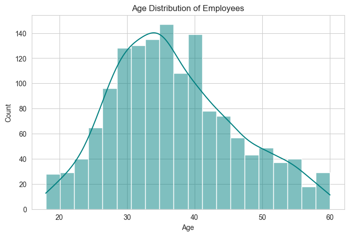

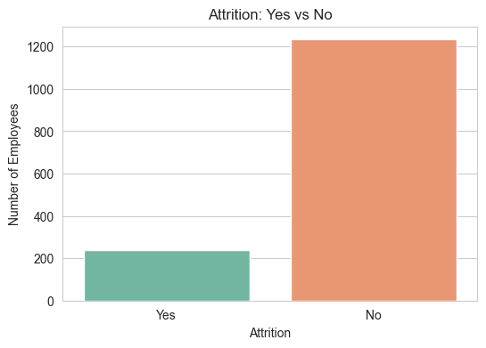

```
C:\Users\Vuyo M\AppData\Local\Temp\ipykernel_10468\3353988964.py:2: FutureWarning:

Passing `palette` without assigning `hue` is deprecated and will be removed in v0.14.0. Assign the `x` variable to `hue` and set `legend=False` for the same effect.

  sns.countplot(x='JobSatisfaction', data=df, palette='viridis')
```

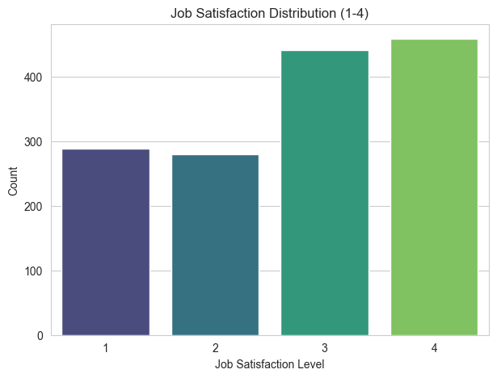

```
C:\Users\Vuyo M\AppData\Local\Temp\ipykernel_10468\2164895111.py:2: FutureWarning:

Passing `palette` without assigning `hue` is deprecated and will be removed in v0.14.0. Assign the `x` variable to `hue` and set `legend=False` for the same effect.

  sns.boxplot(x='Attrition', y='MonthlyIncome', data=df, palette='coolwarm')
```

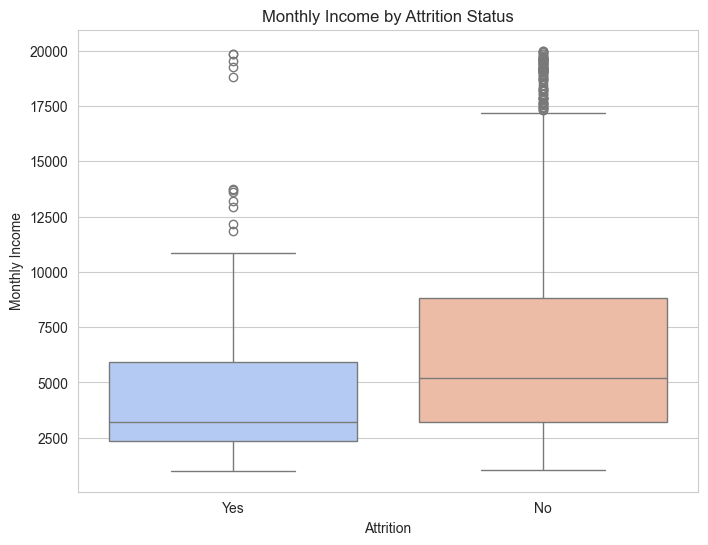

```
HR Insight: Employees who left had lower median income.
```

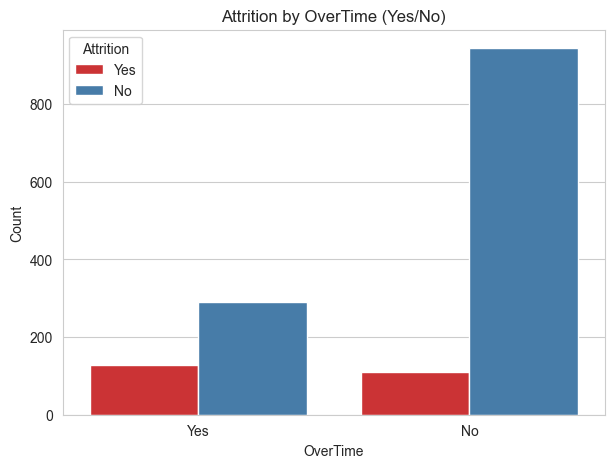

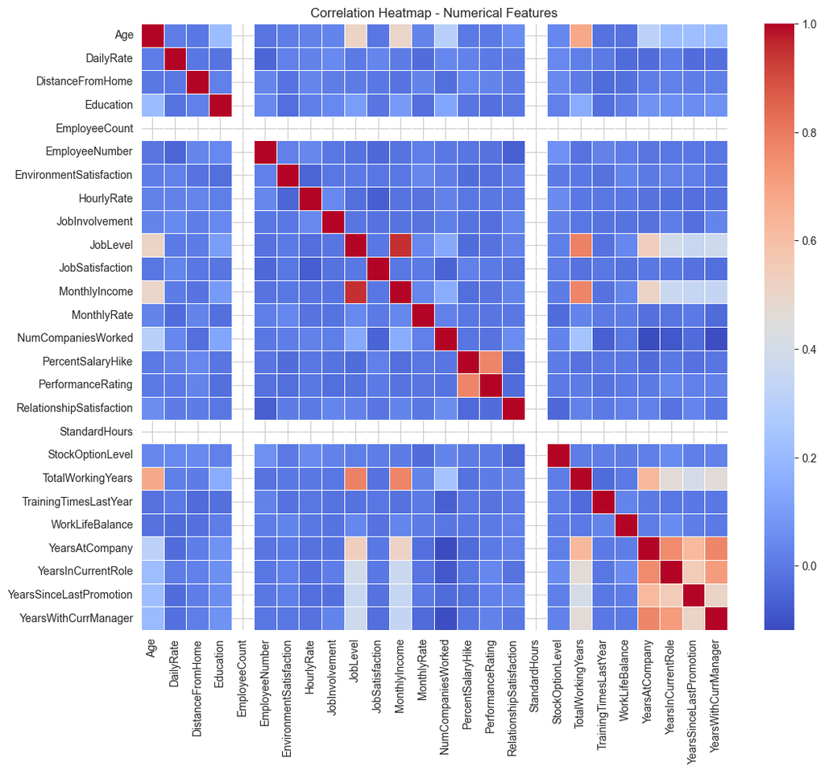

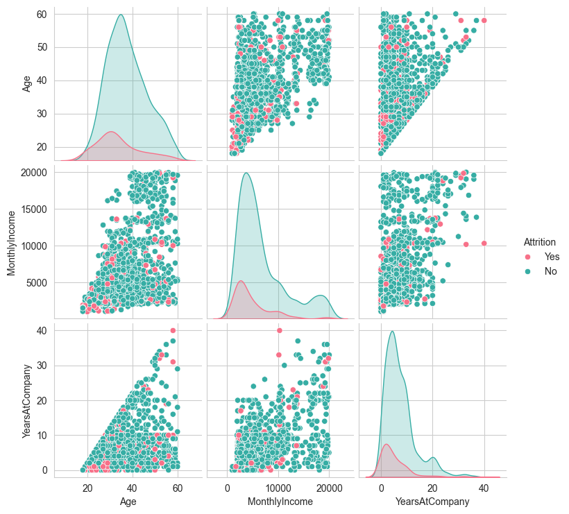

## Key HR Insights from EDA

- Attrition rate: 16.1% - high enough to impact costs and morale.
- Overtime impact: 30.5% attrition when OverTime = Yes (vs 10.4% No) - major burnout driver.
- Income age: Leavers have lower median monthly income - possible dissatisfaction trigger.
- Age & tenure: Employees under 35 and with <5 years tenure show higher turnover.
- Satsifaction: Lower Job & Environment satisfaction strongly linked to leaving.

## Actionable Recommendations

1. Reduce overtime exposure
- Conduct overtime audits and cap weekly hours (align with BCEA limits).
- Introduce flexible shifts or compensatory time-off for high-overtime roles.
2. Address salary equity
- Benchmark MonthlyIncome against market rates for role with high attrition (sales, young employees).
- Implement targeted salary adjustment or performance-linked bonuses for at-risk groups.
3. Support early-career employees
- Launch mentorship programs for staff under 35 and <5 years tenure.
- Run quartly engagemnt surveys found on young employees.
4. Improve satisfaction & work-life balance
- Roll out wellness initiatives (e.g EAP programs, mental health days).
- Train managers on creating supportive environments (target low jobsatisfaction scores).
5. Monitor & follow up
- Track attrition monthly by Department, OverTime and Age Group.
- Set KPI: Reduce attrition by 20% in high-risk groups within 12 months.

These targeted actions can lower turnover costs and improve employee retention.